# Single-term presidents vs multi-term presidents

## Did their speeches differ?

In this project, I looked at the presidents’ inauguation speeches for those who belong to either Democratic or Republican parties. I compared the presidents who only served one-term to those who served multiple terms, and tried to find if there are any differences.

# Step 1: Install and load packages

```r
rm(list=ls())
# check packages that need to be installed.
packages.used=c("readxl","readr","tm", "wordcloud", "RColorBrewer", "dplyr",
                "tidytext","rvest","tibble","qdap","sentimentr",
                "gplots","syuzhet","factoextra","beeswarm","scales",
                "RColorBrewer","RANN","topicmodels","ggplot2","reshape")
packages.needed=setdiff(packages.used, intersect(installed.packages()[,1], packages.used))
# install additional packages
if(length(packages.needed)>0){
  install.packages(packages.needed, dependencies = TRUE,repos='http://cran.us.r-project.org')
}
# load packages
library(readxl)
library(readr)
library(tm)
library(wordcloud)
library(RColorBrewer)
library(dplyr)
library(tidytext)
library(rvest)
library(tibble)
library(qdap)
library(sentimentr)
library(gplots)
library(syuzhet)
library(factoextra)
library(beeswarm)
library(scales)
library(RColorBrewer)
library(RANN)
library(topicmodels)
library(ggplot2)
library(reshape)
```

```r
print(R.version)
```

```
               _
platform       x86_64-apple-darwin13.4.0
arch           x86_64
os             darwin13.4.0
system         x86_64, darwin13.4.0
status
major          3
minor          3.2
year           2016
month          10
day            31
svn rev        71607
language       R
version.string R version 3.3.2 (2016-10-31)
nickname       Sincere Pumpkin Patch
```

# Step 2: Pre-processing

### Group data - Republicans & Democrats

```r
# Group data
# Republicans vs Democrats
inaug_info <- read_excel("../data/InaugurationInfo.xlsx")
inaug_info_GOP <- inaug_info[inaug_info$Party=='Republican',]
inaug_info_DNC <- inaug_info[inaug_info$Party=='Democratic',]
inaug_info <- rbind(inaug_info_GOP,inaug_info_DNC) #Removing those who are not GOP or DNC.
dim(inaug_info_GOP)
```

```
[1] 24  5
```

```r
dim(inaug_info_DNC)
```

```
[1] 22  5
```

```r
dim(inaug_info)
```

```
[1] 46  5
```

### Group data - single-term & multi-term presidents

```r
# Speeches of presidents who served multiple terms vs one term
multi_term_pres <- inaug_info[inaug_info$Term!='1',]
one_term_pres <- inaug_info[-which(inaug_info$President %in% multi_term_pres$President),]
multi_term_pres <- inaug_info[which(inaug_info$President %in% multi_term_pres$President),]
# handle an exception -- Grover Cleveland
one_term_pres <- one_term_pres[one_term_pres$President != 'Grover Cleveland - I',]
multi_term_pres <- rbind(multi_term_pres,inaug_info[inaug_info$President=='Grover Cleveland - I',])
# Add a column to identify one-term or multi-term president.
one_term_pres$Type <- 'Single-Term'
multi_term_pres$Type <- 'Multi-Term'
inaug_info <- rbind(one_term_pres,multi_term_pres)
# Check and overwrite inaug_info.
dim(one_term_pres)
```

```
[1] 18  6
```

```r
dim(multi_term_pres)
```

```
[1] 28  6
```

```r
inaug_info <- rbind(one_term_pres,multi_term_pres)
```

### Add text data & NRC sentiments to the inaug_info file

```r
# Pre-processing
folder.path="../data/InauguralSpeeches/"
# Add text to the inaug_info df.
inaug_info$fulltext <- NA
for(i in seq(nrow(inaug_info))){
  original_file = paste0("inaug", as.vector(inaug_info$File[i]),
                         "-",as.vector(inaug_info$Term[i]),".txt")
  text = read_file(file.path(folder.path, original_file))
  inaug_info$fulltext[i]=text
}
inaug_info
```

|  | President | File | Term | Party | Words | Type | fulltext |
| --- | --- | --- | --- | --- | --- | --- | --- |
| 1 | Rutherford B. Hayes | RutherfordBHayes | 1 | Republican | 2486 | Single-Term | Fellow-Citizens:We have assembled to repeat the public ceremonial, begun by Washington, observed by all my predecessors, and now a time-honored custom, which marks the commencement of a new term of th… |
| 2 | James Garfield | JamesGarfield | 1 | Republican | 2979 | Single-Term | Fellow-Citizens:We stand to-day upon an eminence which overlooks a hundred years of national life--a century crowded with perils, but crowned with the triumphs of liberty and law. Before continuing th… |
| 3 | Benjamin Harrison | BenjaminHarrison | 1 | Republican | 4392 | Single-Term | Fellow-Citizens:There is no constitutional or legal requirement that the President shall take the oath of office in the presence of the people, but there is so manifest an appropriateness in the publi… |
| 4 | Theodore Roosevelt | TheodoreRoosevelt | 1 | Republican | 984 | Single-Term | My fellow-citizens,No people on earth have more cause to be thankful than ours, and this is said reverently, in no spirit of boastfulness in our own strength, but with gratitude to the Giver of Good w… |
| 5 | William Howard Taft | WilliamHowardTaft | 1 | Republican | 5434 | Single-Term | My Fellow-Citizens:Anyone who has taken the oath I have just taken must feel a heavy weight of responsibility. If not, he has no conception of the powers and duties of the office upon which he is abou… |
| 6 | Warren G. Harding | WarrenGHarding | 1 | Republican | 3329 | Single-Term | When one surveys the world about him after the great storm, noting the marks of destruction and yet rejoicing in the ruggedness of the things which withstood it, if he is an American he breathes the c… |
| 7 | Calvin Coolidge | CalvinCoolidge | 1 | Republican | 4055 | Single-Term | My Countrymen:No one can contemplate current conditions without finding much that is satisfying and still more that is encouraging. Our own country is leading the world in the general readjustment to … |
| 8 | Herbert Hoover | HerbertHoover | 1 | Republican | 3672 | Single-Term | [Delivered in person at the Capitol]My countrymen:This occasion is not alone the administration of the most sacred oath which can be assumed by an American citizen. It is a dedication and consecration… |
| 9 | George Bush | GeorgeBush | 1 | Republican | 2320 | Single-Term | Mr. Chief Justice, Mr. President, Vice President Quayle, Senator Mitchell, Speaker Wright, Senator Dole, Congressman Michel, and fellow citizens, neighbors, and friends: There is a man here who has ea… |
| 10 | Donald J. Trump | DonaldJTrump | 1 | Republican | TBD | Single-Term | Chief Justice Roberts, President Carter, President Clinton, President Bush, President Obama, fellow Americans and people of the world, thank you.\n\n We, the citizens of America, are now joined in a g… |

[output cut: 36 more lines]

```r
#Create a sentence list with NRC sentiments
sentence.list<-NULL
for(i in 1:nrow(inaug_info)){
  sentences=sent_detect(inaug_info$fulltext[i],endmarks = c("?", ".", "!", "|",";"))
  if(length(sentences)>0){
    emotions=get_nrc_sentiment(sentences)
    word_count=word_count(sentences)
    emotions=diag(1/(word_count+0.01))%*%as.matrix(emotions)
    sentence.list=rbind(sentence.list,
                        cbind(inaug_info[i,-ncol(inaug_info)],
                              sentences=as.character(sentences),
                              word_count,
                              emotions,
                              sent_id=1:length(sentences)
                        )
    )
  }
}
sentence.list= sentence.list%>% filter(!is.na(word_count))
summary(sentence.list)
```

```
  President             File                Term          Party
 Length:4703        Length:4703        Min.   :1.000   Length:4703
 Class :character   Class :character   1st Qu.:1.000   Class :character
 Mode  :character   Mode  :character   Median :1.000   Mode  :character
                                       Mean   :1.282
                                       3rd Qu.:2.000
                                       Max.   :4.000

    Words               Type                                              sentences
 Length:4703        Length:4703        Thank you.                              :   7
 Class :character   Class :character   Mr.                                     :   6
 Mode  :character   Mode  :character   Chief Justice, Mr.                      :   5
                                       Amen.                                   :   3
                                       Vice President, Mr.                     :   3
                                       The Constitution does not expressly say.:   3
                                       (Other)                                 :4676
   word_count         anger          anticipation        disgust
 Min.   :  1.00   Min.   :0.00000   Min.   :0.00000   Min.   :0.000000
 1st Qu.: 12.00   1st Qu.:0.00000   1st Qu.:0.00000   1st Qu.:0.000000
 Median : 19.00   Median :0.00000   Median :0.00000   Median :0.000000
 Mean   : 22.27   Mean   :0.01567   Mean   :0.03474   Mean   :0.009346
 3rd Qu.: 29.00   3rd Qu.:0.01709   3rd Qu.:0.05552   3rd Qu.:0.000000
 Max.   :110.00   Max.   :0.33223   Max.   :0.66445   Max.   :0.332779

      fear              joy             sadness           surprise
 Min.   :0.00000   Min.   :0.00000   Min.   :0.00000   Min.   :0.00000
 1st Qu.:0.00000   1st Qu.:0.00000   1st Qu.:0.00000   1st Qu.:0.00000
 Median :0.00000   Median :0.00000   Median :0.00000   Median :0.00000
 Mean   :0.02767   Mean   :0.03336   Mean   :0.01468   Mean   :0.01262
 3rd Qu.:0.04346   3rd Qu.:0.05260   3rd Qu.:0.00000   3rd Qu.:0.00000
 Max.   :0.49875   Max.   :0.99010   Max.   :0.33296   Max.   :0.24938

     trust            negative          positive          sent_id
 Min.   :0.00000   Min.   :0.00000   Min.   :0.00000   Min.   :  1.0
 1st Qu.:0.00000   1st Qu.:0.00000   1st Qu.:0.02409   1st Qu.: 26.0
 Median :0.04760   Median :0.00000   Median :0.07686   Median : 54.0
 Mean   :0.05912   Mean   :0.03773   Mean   :0.08645   Mean   : 61.3
 3rd Qu.:0.09083   3rd Qu.:0.06060   3rd Qu.:0.12493   3rd Qu.: 90.0
 Max.   :0.99502   Max.   :0.49875   Max.   :0.99502   Max.   :200.0
```

### Group speech files into directories by term length

```r
### Create a dir for multi_term presidents' speeches
dir.create(file.path(folder.path, "multi_term"),showWarnings = FALSE)
for(i in seq(nrow(multi_term_pres))){
  original_file = paste0("inaug", as.vector(multi_term_pres$File[i]),
                    "-",as.vector(multi_term_pres$Term[i]),".txt")
  text = read_file(file.path(folder.path, original_file))
  new_file <- paste0(folder.path, "multi_term/", original_file)
  sink(file = new_file) %>%
    cat(text)  # write the file
  sink()
}
### Create a dir for single_term presidents' speeches
dir.create(file.path(folder.path, "single_term"),showWarnings = FALSE)
for(i in seq(nrow(one_term_pres))){
  original_file = paste0("inaug", as.vector(one_term_pres$File[i]),
                         "-",as.vector(one_term_pres$Term[i]),".txt")
  text = read_file(file.path(folder.path, original_file))
  new_file <- paste0(folder.path, "single_term/", original_file)
  sink(file = new_file) %>%
    cat(text)  # write the file
  sink()
}
```

# Step 3 Data Analysis - word cloud & frequent words

First, let’s look at what kind of words were used in the speeches, and if there are any significant differences between the two groups (single-term vs multi-term).

```r
###############################################################
#### Word cloud & frequent words
###############################################################
single_term_path <- paste0(folder.path, "single_term/")
multi_term_path <- paste0(folder.path, "multi_term/")
single_term_speeches =list.files(path = single_term_path, pattern = "*.txt")
multi_term_speeches=list.files(path = multi_term_path, pattern = "*.txt")
noprex_single_term_sp=substr(single_term_speeches, 6, nchar(single_term_speeches)-4)
noprex_multi_term_sp=substr(multi_term_speeches, 6, nchar(multi_term_speeches)-4)
ff_single_term <- Corpus(DirSource(single_term_path))
ff_multi_term <- Corpus(DirSource(multi_term_path))
cleanupCorpus <- function(ff){
  ff<-tm_map(ff, stripWhitespace)
  ff<-tm_map(ff, content_transformer(tolower))
  ff<-tm_map(ff, removeWords, stopwords("english"))
  ff<-tm_map(ff, removeWords, character(0))
  ff<-tm_map(ff, removePunctuation)
}
ff_single_term = cleanupCorpus(ff_single_term)
ff_multi_term = cleanupCorpus(ff_multi_term)
tdm_single <- TermDocumentMatrix(ff_single_term)
tdm_single_tidy = tidy(tdm_single)
tdm_single_overall=summarise(group_by(tdm_single_tidy, term), sum(count))
tdm_multi <- TermDocumentMatrix(ff_multi_term)
tdm_multi_tidy = tidy(tdm_multi)
tdm_multi_overall=summarise(group_by(tdm_multi_tidy, term), sum(count))
print('single-term presidents\' frequent terms')
```

```
[1] "single-term presidents' frequent terms"
```

```r
findFreqTerms(tdm_single,100)
```

```
 [1] "can"        "country"    "every"      "government" "great"      "may"
 [7] "must"       "nation"     "nations"    "new"        "people"     "shall"
[13] "states"     "upon"       "will"       "world"
```

```r
print('multi-term presidents\' frequent terms')
```

```
[1] "multi-term presidents' frequent terms"
```

```r
findFreqTerms(tdm_multi,100)
```

[output not shown]

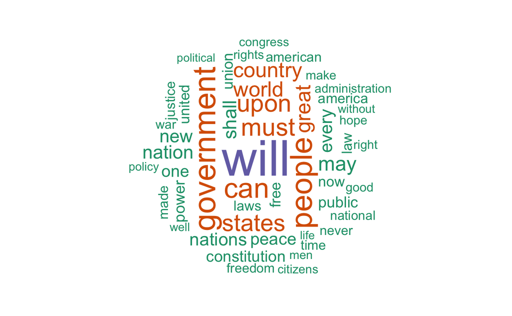

```r
set.seed(123)
wordcloud(tdm_single_overall$term, tdm_single_overall$`sum(count)`,
          scale=c(4,0.5),
          max.words=50,
          min.freq=1,
          random.order=FALSE,
          rot.per=0.2,
          use.r.layout=T,
          random.color=FALSE,
          colors=brewer.pal(3,"Dark2"))
```

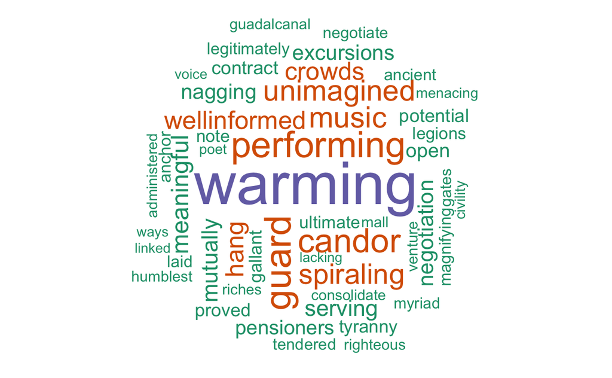

```r
wordcloud(tdm_multi_overall$term, tdm_single_overall$`sum(count)`,
          scale=c(4,0.5),
          max.words=50,
          min.freq=1,
          random.order=FALSE,
          rot.per=0.2,
          use.r.layout=T,
          random.color=FALSE,
          colors=brewer.pal(3,"Dark2"))
```

Did multi-term presidents tend to use more emotionally-charged words? And did single-term presidents tend to be more formal?

Let’s find out.

# Step 4 Data Analysis - sentiment analysis

In this section, I looked at the magnitude and types of emotions contained in each sentence used by two groups.

Furthermore, I separated multi-term presidents’ speeches into two groups, because I wondered if their first speeches are actually similar to those by the single-term presidents, and they may become more relaxed for their 2nd speeches.

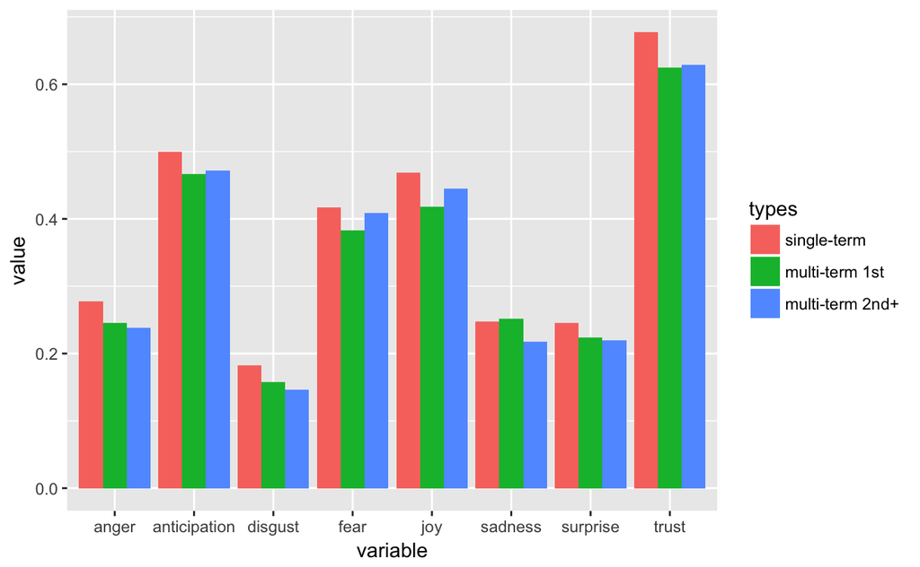

```r
# Mean of each emotion score by group
single_emo_means=colMeans(sentence.list%>%
                            filter(Type=="Single-Term")%>%
                            select(anger:trust)>0.01)
multi_emo_means1=colMeans(sentence.list%>%
                            filter(Type=="Multi-Term",Term==1)%>%
                            select(anger:trust)>0.01)
multi_emo_means2=colMeans(sentence.list%>%
                            filter(Type=="Multi-Term",Term!=1)%>%
                            select(anger:trust)>0.01)
# Merge them as a df.
types = c("single-term","multi-term 1st","multi-term 2nd+")
emo_means = data.frame(types,
                       rbind(single_emo_means,multi_emo_means1,multi_emo_means2),
                       row.names=NULL)
emo_means$types <- factor(emo_means$types, as.character(emo_means$types))
emo_means.m = melt(emo_means,id.vars='types')
# Plot a grouped bar chart
ggplot(emo_means.m, aes(variable, value)) +
  geom_bar(aes(fill = types), position = "dodge", stat="identity")
```

Unlike what I assumed from looking at the Word Clouds, single-term presidents’ sentences tend to have higher scores for emotions.

Let’s look at some of those emotional sentences.

```r
### What are the emotionally charged sentences?
print("##### Single Term #####")
```

```
[1] "##### Single Term #####"
```

```r
speech.df=tbl_df(sentence.list)%>%
  filter(Type=="Single-Term", word_count>=5)%>%
  select(President, sentences, anger:trust)
speech.df=as.data.frame(speech.df)
as.character(speech.df$sentences[apply(speech.df[,-c(1:2)], 2, which.max)])
```

```
[1] "The evil works from a bad center both ways."
[2] "But hope is good, and so is strength and vigilance."
[3] "The evil works from a bad center both ways."
[4] "We know that self-government is difficult."
[5] "Beneath its benign sway peace and prosperity prevail."
[6] "There are the homeless, lost and roaming."
[7] "But this peaceful revolution of hope cannot become the prey of hostile powers."
[8] "The past and present show faith and hope and courage fully justified."
```

```r
print("##### Multi Term - 1st speech #####")
```

```
[1] "##### Multi Term - 1st speech #####"
```

```r
speech.df=tbl_df(sentence.list)%>%
  filter(Type=="Multi-Term", Term == 1, word_count>=5)%>%
  select(President, sentences, anger:trust)
speech.df=as.data.frame(speech.df)
as.character(speech.df$sentences[apply(speech.df[,-c(1:2)], 2, which.max)])
```

```
[1] "Whoever rejects it does of necessity fly to anarchy or to despotism."
[2] "God bless you, and thank you."
[3] "With riches has come inexcusable waste."
[4] "Abandonment and abuse are not acts of God;"
[5] "God bless you, and thank you."
[6] "Whoever rejects it does of necessity fly to anarchy or to despotism."
[7] "This hope--this supreme aspiration--must rule the way we live."
[8] "This hope--this supreme aspiration--must rule the way we live."
```

```r
print("##### Multi Term - 2nd+ speech #####")
```

```
[1] "##### Multi Term - 2nd+ speech #####"
```

```r
speech.df=tbl_df(sentence.list)%>%
  filter(Type=="Multi-Term", Term != 1, word_count>=5)%>%
  select(President, sentences, anger:trust)
speech.df=as.data.frame(speech.df)
as.character(speech.df$sentences[apply(speech.df[,-c(1:2)], 2, which.max)])
```

```
[1] "We have always known that heedless self-interest was bad morals;"
[2] "to the elevation of labor;"
[3] "We have always known that heedless self-interest was bad morals;"
[4] "They fuel the fanaticism of terror."
[5] "to the elevation of labor;"
[6] "Dark pictures and gloomy forebodings are worse than useless."
[7] "We are moving toward an era of good feeling."
[8] "to the elevation of labor;"
```

# Step 5 Data Analysis - topic modeling

In this section, I looked at if there are any differences in topics discussed in the speeches of single-term presidents v.s. multi-term presidents.

```r
# prepare snipets
corpus.list=sentence.list[2:(nrow(sentence.list)-1), ]
sentence.pre=sentence.list$sentences[1:(nrow(sentence.list)-2)]
sentence.post=sentence.list$sentences[3:(nrow(sentence.list)-1)]
corpus.list$snipets=paste(sentence.pre, corpus.list$sentences, sentence.post, sep=" ")
rm.rows=(1:nrow(corpus.list))[corpus.list$sent_id==1]
rm.rows=c(rm.rows, rm.rows-1)
corpus.list=corpus.list[-rm.rows, ]
docs <- Corpus(VectorSource(corpus.list$snipets))
set.seed(123)
writeLines(as.character(docs[[sample(1:nrow(corpus.list), 1)]]))
```

```
We will seek friendship and goodwill with the nations of the world, but we do so with the understanding that it is the right of all nations to put their own interests first. We do not seek to impose our way of life on anyone, but rather to let it shine as an example. We will shine for everyone to fo…
```

```r
docs = cleanupCorpus(docs) # the function we used for the word cloud corpus
docs = tm_map(docs, removeNumbers)
docs = tm_map(docs,stemDocument)
set.seed(123)
writeLines(as.character(docs[[sample(1:nrow(corpus.list), 1)]]))
```

```
will seek friendship goodwil nation world understand right nation put interest first seek impo way life anyon rather let shine exampl will shine everyon follow
```

```r
dtm <- DocumentTermMatrix(docs)
#convert rownames to filenames
rownames(dtm)=paste(substr(corpus.list$Type, 1, nchar(corpus.list$Type)-5),
                    corpus.list$File, corpus.list$Term,
                    corpus.list$sent_id, sep="_")
rowTotals=apply(dtm, 1, sum) #sum of words in each doc
dtm = dtm[rowTotals>0, ]
corpus.list=corpus.list[rowTotals>0, ]
```

### Let’s run LDA with Gibbs sampling

```r
#LDA with Gibbs
burnin = 1000
iter = 2000
thin = 200
seed = list(6558,7,631,10009,4921)
nstart = 5
best = TRUE
k=15 #num of topics
set.seed(123)
ldaOut <-LDA(dtm, k, method="Gibbs", control=list(nstart=nstart,
                                                  seed = seed, best=best,
                                                  burnin = burnin, iter = iter,
                                                  thin=thin))
```

```r
#write out results
#docs to topics
ldaOut.topics <- as.matrix(topics(ldaOut))
table(c(1:k, ldaOut.topics))
```

```
  1   2   3   4   5   6   7   8   9  10  11  12  13  14  15
398 330 309 318 252 335 392 410 325 416 206 217 330 161 227
```

```r
dir.create(file.path('output/LDAGibbs'),showWarnings = FALSE)
write.csv(ldaOut.topics,file=paste0("../output/LDAGibbs/",k,"DocsToTopics.csv"))
#top 10 terms in each topic
ldaOut.terms <- as.matrix(terms(ldaOut,10))
write.csv(ldaOut.terms,file=paste0("../output/LDAGibbs/",k,"TopicsToTerms.csv"))
#probabilities associated with each topic assignment
topicProbabilities <- as.data.frame(ldaOut@gamma)
write.csv(topicProbabilities,file=paste0("../output/LDAGibbs/",k,"TopicProbabilities.csv"))
```

```r
terms.beta=ldaOut@beta
terms.beta=scale(terms.beta)
ldaOut.terms
```

```
      Topic 1     Topic 2    Topic 3   Topic 4     Topic 5    Topic 6     Topic 7
 [1,] "state"     "countri"  "shall"   "law"       "upon"     "govern"    "freedom"
 [2,] "govern"    "industri" "duti"    "right"     "question" "public"    "free"
 [3,] "power"     "product"  "upon"    "shall"     "parti"    "interest"  "men"
 [4,] "constitut" "increas"  "peopl"   "citizen"   "principl" "congress"  "life"
 [5,] "unit"      "trade"    "may"     "protect"   "countri"  "necessari" "man"
 [6,] "union"     "great"    "offic"   "respect"   "polit"    "may"       "know"
 [7,] "peopl"     "use"      "best"    "enforc"    "import"   "revenu"    "long"
 [8,] "preserv"   "econom"   "support" "execut"    "action"   "proper"    "equal"
 [9,] "right"     "progress" "servic"  "secur"     "made"     "provid"    "human"
[10,] "limit"     "home"     "faith"   "constitut" "express"  "economi"   "see"
      Topic 8   Topic 9    Topic 10   Topic 11  Topic 12  Topic 13   Topic 14 Topic 15
 [1,] "time"    "american" "new"      "great"   "peopl"   "nation"   "will"   "can"
 [2,] "year"    "everi"    "america"  "never"   "without" "world"    "one"    "must"
 [3,] "day"     "hope"     "let"      "countri" "civil"   "peac"     "now"    "peopl"
 [4,] "god"     "liberti"  "work"     "much"    "purpos"  "war"      "make"   "nation"
 [5,] "presid"  "chang"    "make"     "futur"   "common"  "seek"     "believ" "thing"
 [6,] "histori" "mean"     "togeth"   "danger"  "republ"  "forc"     "good"   "help"
 [7,] "centuri" "land"     "old"      "mani"    "good"    "strength" "give"   "act"
 [8,] "first"   "generat"  "better"   "fear"    "justic"  "way"      "hope"   "hand"
 [9,] "now"     "faith"    "live"     "exist"   "advanc"  "secur"    "feel"   "done"
[10,] "today"   "children" "opportun" "look"    "order"   "polici"   "race"   "other"
```

### Naming the topics

Rather than guessing the names from terms, I combined the first 3 terms to make them the “Topic name”.

```r
# Create topic labels by combining the first 3 terms
topics.terms= ldaOut.terms
topics.hash = NULL
for (i in 1:k){
  topic.name = paste(topics.terms[1,i],topics.terms[2,i],
             topics.terms[3,i], sep='-')
  topics.hash = c(topics.hash,topic.name)
}
topics.hash # list of topics
```

```
 [1] "state-govern-power"       "countri-industri-product" "shall-duti-upon"
 [4] "law-right-shall"          "upon-question-parti"      "govern-public-interest"
 [7] "freedom-free-men"         "time-year-day"            "american-everi-hope"
[10] "new-america-let"          "great-never-countri"      "peopl-without-civil"
[13] "nation-world-peac"        "will-one-now"             "can-must-peopl"
```

```r
colnames(topics.terms) = topic.vec
corpus.list$ldatopic=as.vector(ldaOut.topics)
corpus.list$ldahash=topics.hash[ldaOut.topics]
colnames(topicProbabilities)=topics.hash
corpus.list.df=cbind(corpus.list, topicProbabilities)
```

### Clustering

```r
#clustering
par(mar=c(1,1,1,1))
topic.summary=tbl_df(corpus.list.df)%>%
  filter(Type == "Single-Term")%>%
  select(File, 23:37)%>%
  group_by(File)%>%
  summarise_all(funs(mean))
topic.summary=as.data.frame(topic.summary)
rownames(topic.summary)=topic.summary[,1]
topic.plot=1:15
#topic.plot=c(1, 2, 4, 9, 13, 9, 11, 8, 3, 2, 7)
print(topics.hash[topic.plot])
```

```
 [1] "state-govern-power"       "countri-industri-product" "shall-duti-upon"
 [4] "law-right-shall"          "upon-question-parti"      "govern-public-interest"
 [7] "freedom-free-men"         "time-year-day"            "american-everi-hope"
[10] "new-america-let"          "great-never-countri"      "peopl-without-civil"
[13] "nation-world-peac"        "will-one-now"             "can-must-peopl"
```

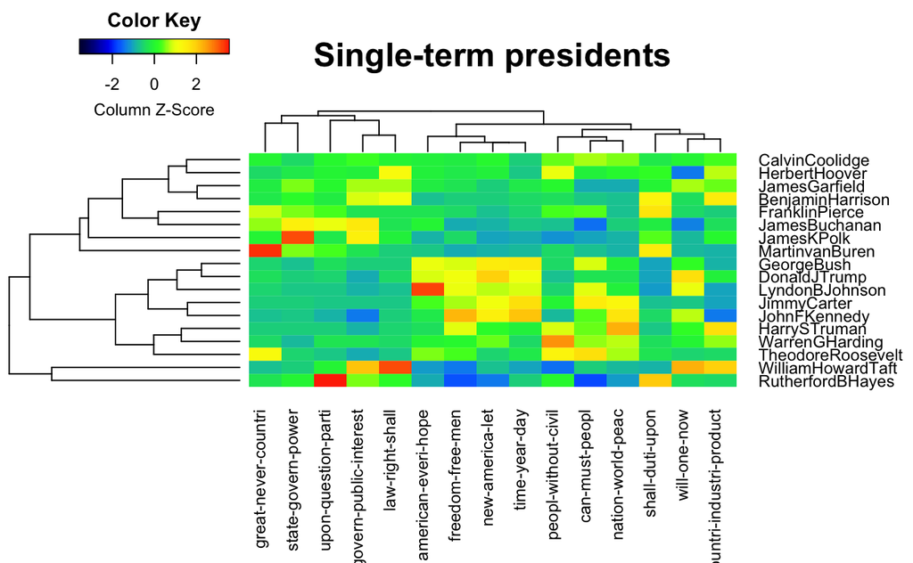

```r
heatmap.2(as.matrix(topic.summary[,topic.plot+1]),
          scale = "column",
          col = rich.colors(100),
          cexRow = 0.9, cexCol = 0.9, margins = c(8, 8),
          trace = "none", density.info = "none",
          main = "Single-term presidents")
par(mar=c(1,1,1,1))
```

```r
topic.summary=tbl_df(corpus.list.df)%>%
  filter(Type == "Multi-Term")%>%
  select(File, 23:37)%>%
  group_by(File)%>%
  summarise_all(funs(mean))
topic.summary=as.data.frame(topic.summary)
rownames(topic.summary)=topic.summary[,1]
topic.plot=c(1, 13, 9, 11, 8, 3, 7)
topic.plot=1:15
print(topics.hash[topic.plot])
```

```
 [1] "state-govern-power"       "countri-industri-product" "shall-duti-upon"
 [4] "law-right-shall"          "upon-question-parti"      "govern-public-interest"
 [7] "freedom-free-men"         "time-year-day"            "american-everi-hope"
[10] "new-america-let"          "great-never-countri"      "peopl-without-civil"
[13] "nation-world-peac"        "will-one-now"             "can-must-peopl"
```

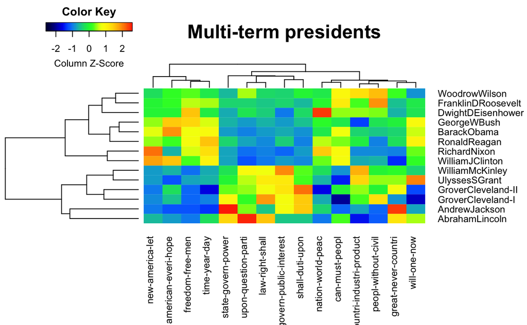

```r
heatmap.2(as.matrix(topic.summary[,topic.plot+1]),
          scale = "column",
          col = rich.colors(100),
          cexRow = 0.9, cexCol = 0.9, margins = c(8, 8),
          trace = "none", density.info = "none",
          main = "Multi-term presidents")
```

Some presidents really focused on a topic, while others spread across multiple topics. Recent multi-term presidents talked about freedom, hope, new Americans (immigration?), and world peace.

Recent single-term presidents, including Donald Trump, also talked about similar topics, but they also talked about “will-one-now” which contains words like believ, make, race, good, and give.

Maybe there are more differecences between parties? ###

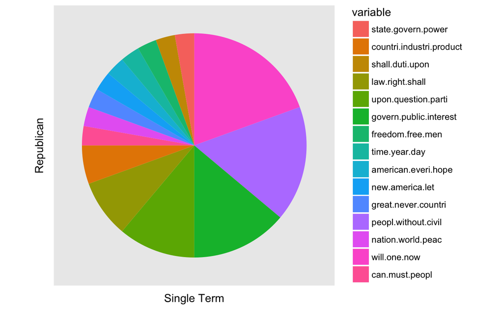

```r
par(mfrow=c(2, 2))
speech.df=tbl_df(corpus.list.df)%>%
  filter(Type == "Single-Term")%>%
  select(Party, 23:37)%>%group_by(Party)%>%
  summarise_all(funs(mean))
speech.df=as.matrix(speech.df)
speech.df[,-1]=replace(speech.df[,-1], speech.df[,-1]<1/15, 0.001)
party = c("Democratic","Republican")
speech.df = data.frame(party,speech.df[,-1],row.names = NULL)
speech.df.m = melt(speech.df,id.vars='party')
speech.df.m.ordered <- speech.df.m[order(speech.df.m$value, decreasing = TRUE),]
speech.df.m.ordered$party <- factor(speech.df.m.ordered$party,
                                    levels = c("Republican","Democratic"))
ggplot(data = subset(speech.df.m.ordered)[speech.df.m.ordered$party=="Republican",],
          aes(x=factor(1),y=value,fill = variable)) +
  geom_bar(width = 1, stat="identity") + coord_polar(theta="y") +
  xlab("Republican") + ylab("Single Term") +
  theme(axis.text = element_blank(),
        axis.ticks = element_blank(),
        panel.grid  = element_blank()
  )
```

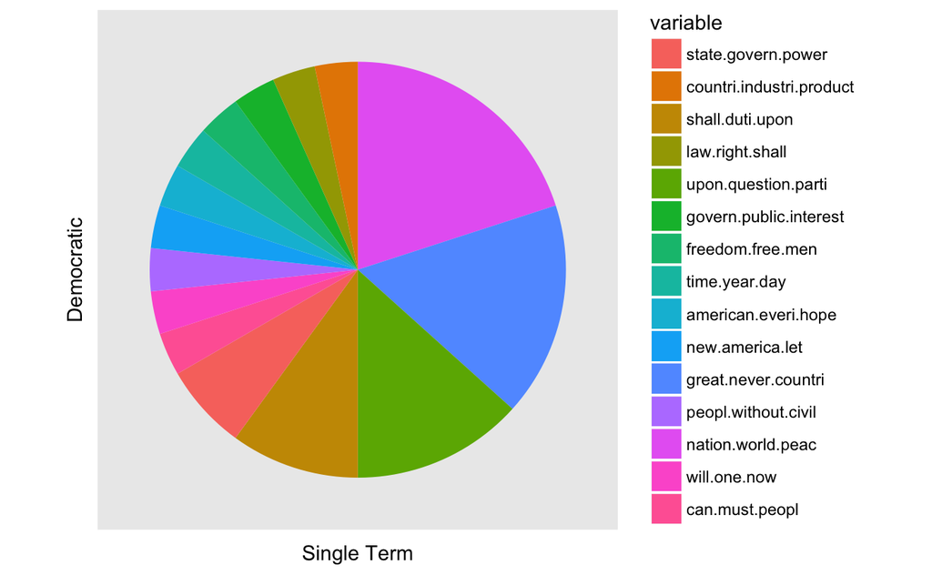

```r
ggplot(data = subset(speech.df.m.ordered)[speech.df.m.ordered$party=="Democratic",],
          aes(x=factor(1),y=value,fill = variable)) +
  geom_bar(width = 1, stat="identity") + coord_polar(theta="y") +
  xlab("Democratic") + ylab("Single Term") +
  theme(axis.text = element_blank(),
        axis.ticks = element_blank(),
        panel.grid  = element_blank())
```

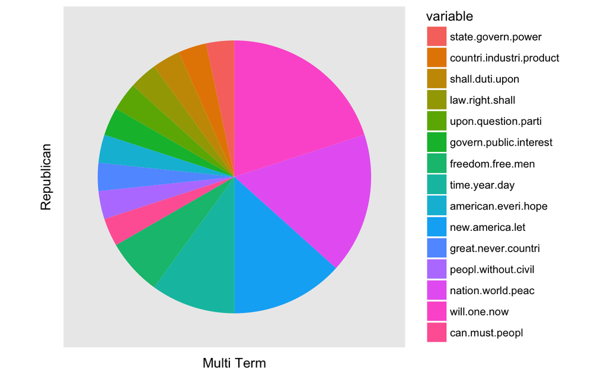

```r
speech.df=tbl_df(corpus.list.df)%>%
  filter(Type == "Multi-Term")%>%
  select(Party, 23:37)%>%group_by(Party)%>%
  summarise_all(funs(mean))
speech.df=as.matrix(speech.df)
speech.df[,-1]=replace(speech.df[,-1], speech.df[,-1]<1/15, 0.001)
party = c("Democratic","Republican")
speech.df = data.frame(party,speech.df[,-1],row.names = NULL)
speech.df.m = melt(speech.df,id.vars='party')
speech.df.m.ordered <- speech.df.m[order(speech.df.m$value, decreasing = TRUE),]
speech.df.m.ordered$party <- factor(speech.df.m.ordered$party,
                                    levels = c("Republican","Democratic"))
ggplot(data = subset(speech.df.m.ordered)[speech.df.m.ordered$party=="Republican",],
          aes(x=factor(1),y=value,fill = variable)) +
  geom_bar(width = 1, stat="identity") + coord_polar(theta="y") +
  xlab("Republican") + ylab("Multi Term") +
  theme(axis.text = element_blank(),
        axis.ticks = element_blank(),
        panel.grid  = element_blank()
  )
```

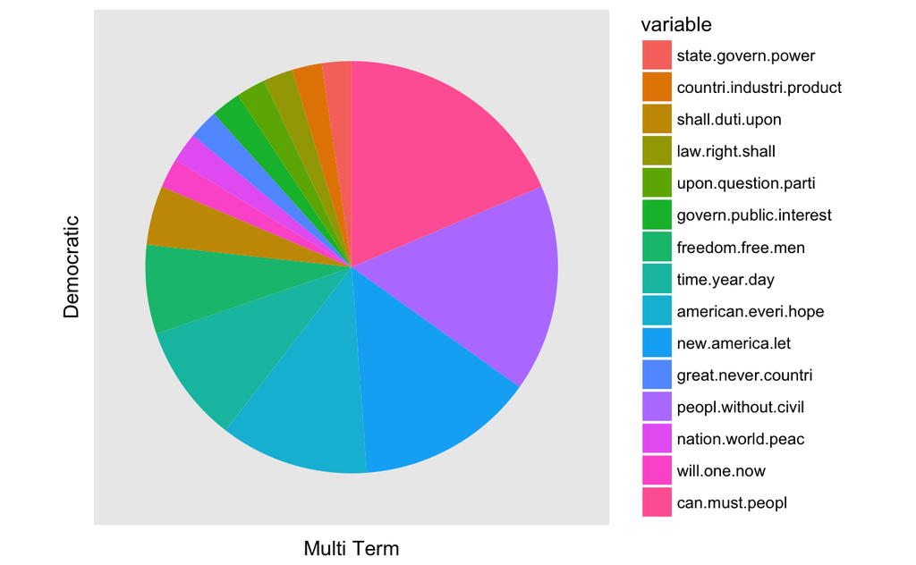

```r
ggplot(data = subset(speech.df.m.ordered)[speech.df.m.ordered$party=="Democratic",],
          aes(x=factor(1),y=value,fill = variable)) +
  geom_bar(width = 1, stat="identity") + coord_polar(theta="y") +
  xlab("Democratic") + ylab("Multi Term") +
  theme(axis.text = element_blank(),
        axis.ticks = element_blank(),
        panel.grid  = element_blank())
```

```r
NA
```

Republicans seem to focus on “will-one-now”, but there are some differences between single- vs multi-term presidents among them.

As the next step of this analysis, it’d be interesting to compare Donald Trump’s speech to those by multi-term presidents and single-term presindents, and see if we can predict he will be elected for the second term.